# Introduction to Statistical Learning - Chapter 10 - Deep Learning - Labs

# Example 03 - Convolutional Neural Network

In this section, we fit a CNN to the `CIFAR100` data set, which is also available in the `keras` package, just like `mnist`, and is arranged in a similar data structure.

## Preprocessing and EDA

```python
# label_mode = 'fine' ensures we have 100 superclasses, not 20 base classes
(X_train, y_train), (X_test, y_test) = cifar100.load_data(label_mode = 'fine')

# Examine shapes of each tensor
print("X_train shape:\t\t", X_train.shape)
print("X_test shape:\t\t", X_test.shape)
print("y_train shape:\t\t", y_train.shape)
print("y_test shape:\t\t", y_test.shape)
```

```
X_train shape:		 (50000, 32, 32, 3)
X_test shape:		 (10000, 32, 32, 3)
y_train shape:		 (50000, 1)
y_test shape:		 (10000, 1)
```

```python
X_train = X_train / 255.0
X_test = X_test / 255.0
y_train = to_categorical(y_train)
y_test = to_categorical(y_test)

print(f"After Encoding Targets")
print("X_train shape:\t\t", X_train.shape)
print("X_test shape:\t\t", X_test.shape)
print("y_train shape:\t\t", y_train.shape)
print("y_test shape:\t\t", y_test.shape)
```

```
After Encoding Targets
X_train shape:		 (50000, 32, 32, 3)
X_test shape:		 (10000, 32, 32, 3)
y_train shape:		 (50000, 100)
y_test shape:		 (10000, 100)
```

Before we start training, we look at some images in the data set.

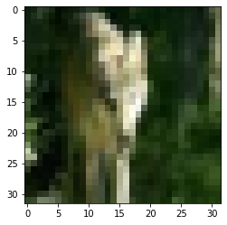

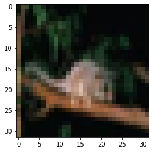

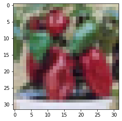

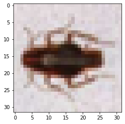

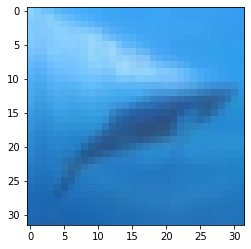

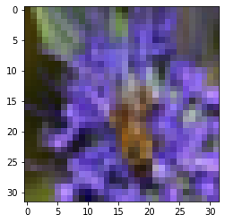

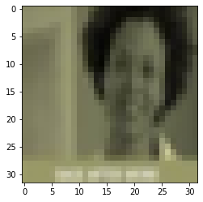

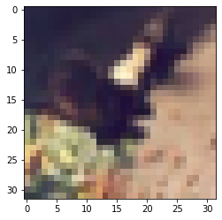

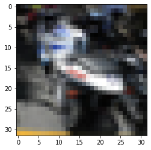

```python
np.random.seed(163)
n_samples = 9
image_sample_idx = np.random.randint(low = 0, high = y_train.shape[0], size = n_samples)

for idx in image_sample_idx:
    my_image = X_train[idx, ]
    plt.figure();
    plt.imshow(my_image);
```

Each image is $32 \times 32$ pixels and has three channels (because it's a full colour image).

## Train CNN

We now instantiate a reasonably sized CNN for demonstration purposes.

```
Model: "sequential_7"
_________________________________________________________________
Layer (type)                 Output Shape              Param #
=================================================================
conv2d_12 (Conv2D)           (None, 32, 32, 32)        896
_________________________________________________________________
max_pooling2d_12 (MaxPooling (None, 16, 16, 32)        0
_________________________________________________________________
conv2d_13 (Conv2D)           (None, 16, 16, 64)        18496
_________________________________________________________________
max_pooling2d_13 (MaxPooling (None, 8, 8, 64)          0
_________________________________________________________________
conv2d_14 (Conv2D)           (None, 8, 8, 128)         73856
_________________________________________________________________
max_pooling2d_14 (MaxPooling (None, 4, 4, 128)         0
_________________________________________________________________
flatten_4 (Flatten)          (None, 2048)              0
_________________________________________________________________
dropout_9 (Dropout)          (None, 2048)              0
_________________________________________________________________
dense_12 (Dense)             (None, 512)               1049088
_________________________________________________________________
dense_13 (Dense)             (None, 100)               51300
=================================================================
Total params: 1,193,636
Trainable params: 1,193,636
Non-trainable params: 0
_________________________________________________________________
```

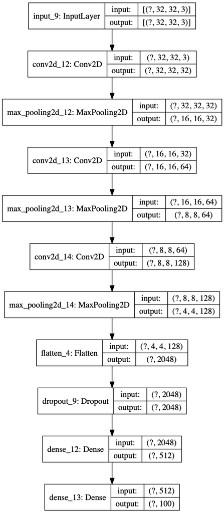

```python
input_dim = (X_train.shape[1], X_train.shape[2], X_train.shape[3])

cifar_cnn = keras.models.Sequential([
    keras.layers.Input(shape = input_dim),

    keras.layers.Conv2D(filters = 32, kernel_size = (3, 3), padding = 'same', activation = 'relu'),
    keras.layers.MaxPooling2D(pool_size = (2, 2)),

    keras.layers.Conv2D(filters = 64, kernel_size = (3, 3), padding = 'same', activation = 'relu'),
    keras.layers.MaxPooling2D(pool_size = (2, 2)),

    keras.layers.Conv2D(filters = 128, kernel_size = (3, 3), padding = 'same', activation = 'relu'),
    keras.layers.MaxPooling2D(pool_size = (2, 2)),

    keras.layers.Flatten(),

    keras.layers.Dropout(rate = 0.5),

    keras.layers.Dense(units = 512, activation = 'relu'),

    keras.layers.Dense(units = 100, activation = 'softmax')
])

# This has a quite a few learnable parameters
cifar_cnn.summary()

plot_model(cifar_cnn, show_shapes = True, show_layer_names = True)
```

We have use `padding = 'same'` argument for each `Conv2D` layer to ensure the output channels have the same dimensins as the input channels.

There are 32 channels in the first hidden layer in contrast to the 3 channels in the original image. The number of channels continues to increase with every `Conv2D` layer.

We have used $2 \times 2$ blocks for pooling and $3 \times 3$ convolutional filter in each layer.

We finally `Flatten` a high-dimensional output from our final `Conv2D`-`MaxPooling2D` layer into a single tensor of high-level features, followed by `Dropout` regularization.

The final layers is a `Dense` softmax over all the classes.

```python
# Specify hyperparameters through compilation and then fit
cifar_cnn.compile(loss = 'categorical_crossentropy',
                 optimizer = 'RMSprop', metrics = ['accuracy'])

cifar_cnn_history = cifar_cnn.fit(
    X_train, y_train, epochs = 30, batch_size = 128, validation_split = 0.2
)
```

```
Train on 40000 samples, validate on 10000 samples
```

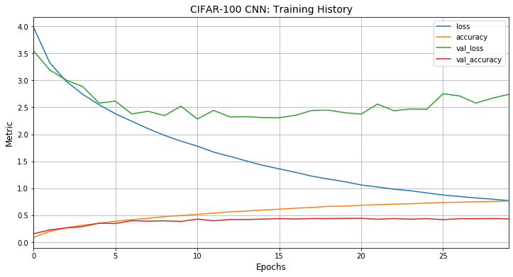

```python
# Plot the history object
pd.DataFrame(cifar_cnn_history.history).plot(figsize = (12, 6));
plt.title("CIFAR-100 CNN: Training History", size = 14);
plt.xlabel('Epochs', size = 12); plt.ylabel('Metric', size = 12);
plt.grid(True);
```

- This model took about 30 minues to train without GPU acceleration.
- Validation accuracy plateaus at ~0.44 by epoch 10, as does validation loss.
- Validation loss actually seems to increase after epoch 10.
- Training loss decreases monotonically with increasing epochs, which we expect.
- Without much tuning, we've achieved performance that is at least half as good as SOTA.

```python
# Generate predictions on the test set
cifar_cnn_pred = cifar_cnn.predict_classes(X_test)
cifar_cnn_accuracy = accuracy_score(y_true = np.argmax(y_test, axis = 1), y_pred = cifar_cnn_pred)

print(f"CIFAR-100 CNN Test Set Accuracy: {np.round(cifar_cnn_accuracy, 2)}")
```

```
CIFAR-100 CNN Test Set Accuracy: 0.45
```

# Example 05 - IMDb Document Classification (Logistic Regression vs ANN)

We now perform document clasificatin using the `IMDb` data set, which is again available as part of the `keras` package.

## Load Data

We begin by limiting the dictionary to consist of the top 10,000 most frequently occurring words.

```python
(X_train, y_train), (X_test, y_test) = imdb.load_data(num_words = 10000)

# What is the shape of the original data?
print("X_train: ", X_train.shape)
print("X_test: ", X_test.shape)
print("y_train: ", y_train.shape)
print("y_test: ", y_test.shape)
```

```
X_train:  (25000,)
X_test:  (25000,)
y_train:  (25000,)
y_test:  (25000,)
```

We have 25,000 training and test examples. Each training example is a vector of integers, with each integer indicating the presence of a particular word in the 10,000 word dictionary.

## Decoding Reviews

```python
X_train[1][1:10] # Look at first 10 words numeric codes
```

```
[194, 1153, 194, 8255, 78, 228, 5, 6, 1463]
```

To see the actual words that these integer indexes represent, we write a function `decode_review`.

```python
# IMDb data has its own internal word-index mapping. Read it as dictionary
word_index = imdb.get_word_index()

# We modify this mapping by reversing key/value pairs, and adding 4 tokens
my_word_keys = list(word_index.keys())
my_word_idx = list(word_index.values())

my_word_keys = ['<PAD>', '<START>', '<UNK>', '<UNUSED>'] + my_word_keys
my_word_idx = [0, 1, 2, 3] + list(np.array(my_word_idx) + 3)

# In our custom word mapping, we perform a lookup on the word index
# and return the corresponding word. If word index is missing, we return <UNK>
custom_word_index = dict(zip(my_word_idx, my_word_keys))

def decode_review(text, word_idx_dict = custom_word_index):
    decoded_text = ' '.join([word_idx_dict.get(word_int, 2) for word_int in text])
    return decoded_text
```

```python
# Initialize a test review that can be used to check `decode_review`
test_review = [
    1, 14, 22, 16, 43, 530, 973, 1622, 1385, 65, 458, 4468
]
decode_review(test_review)
```

```
"<START> this film was just brilliant casting location scenery story direction everyone's"
```

The matches the decoded string that was printed in the book, so our implementation of this function is correct.

## One-Hot Encoding for Bag of Words

We want to write a function that will convert a sequence of integers representing a review into a one-hot encoded tensor of dimension `10,000` (the same as our vocabulary size). When a word appears in the review, its corresponding index in the dictionary is looked up and set to 1. The remainder of the words are 0.

Ideally, this should be a sparse matrix.

```python
# Dictionary size
n_words = 10000

# Initialize empty arrays with one row per sample and one column per word
# Separately for training and test data
X_train_1h = np.zeros(shape = (X_train.shape[0], n_words))
X_test_1h = np.zeros(shape = (X_test.shape[0], n_words))
```

```python
# Iterate over each row in training set, find the corresponding unique words,
# set their indexes in X_train_1h to 1.0
for i in range(X_train.shape[0]):
    X_train_1h[i, np.unique(X_train[i])] = 1.0
```

```python
# Do the same on the test data
for i in range(X_test.shape[0]):
    X_test_1h[i, np.unique(X_test[i])] = 1.0
```

```python
# Check dimensions of train and test matrices
print("X_train: ", X_train.shape)
print("X_train_1h: ", X_train_1h.shape)
print("X_test: ", X_test.shape)
print("X_test_1h: ", X_test_1h.shape)

# Y-dimensions should be unchanged
print("y_train: ", y_train.shape)
print("y_test: ", y_test.shape)
```

```
X_train:  (25000,)
X_train_1h:  (25000, 10000)
X_test:  (25000,)
X_test_1h:  (25000, 10000)
y_train:  (25000,)
y_test:  (25000,)
```

```python
# Check sparsity
print("Non-zero Percentage in Train: ",
      100 * np.count_nonzero(X_train_1h) / X_train_1h.size)

print("Non-zero Percentage in Test: ",
     100 * np.count_nonzero(X_test_1h) / X_test_1h.size)
```

```
Non-zero Percentage in Train:  1.3169872
Non-zero Percentage in Test:  1.2874312
```

Because `keras` does not support `csr_matrix` or other sparse matrix representations as inputs without custom training loops, I choose not to encode this data as sparse matrix. However, dimensionality and proportion of ones align with the `R` implementation.

Before we proceed further, we make a subset of the training data to use as a validation set.

```python
X_train_1h, X_val_1h, y_train, y_val = train_test_split(X_train_1h, y_train, test_size = 2000)

[print(f"{name}: {arr.shape}") for (name, arr) in {
    'X_train_1h': X_train_1h,
    'X_val_1h': X_val_1h,
    'y_train': y_train,
    'y_val': y_val
}.items()];
```

```
X_train_1h: (23000, 10000)
X_val_1h: (2000, 10000)
y_train: (23000,)
y_val: (2000,)
```

## Model 01: Lasso Logistic Regression

First, we fit a lasso logistic regression model to the data, and use cross-validation to find the best regularization parameter $\lambda$ using stratified $K$-fold cross validation.

This won't create the same validation set as the one we've created in earlier steps.

```python
imdb_logreg_cv = LogisticRegressionCV(
    Cs = 10, penalty = 'l1', verbose = 1, cv = 5,
    solver = 'liblinear', scoring = 'accuracy',
    n_jobs = 5
)
imdb_logreg_cv.fit(X_train_1h, y_train)
```

```
[Parallel(n_jobs=5)]: Using backend LokyBackend with 5 concurrent workers.
[Parallel(n_jobs=5)]: Done   2 out of   5 | elapsed:  1.9min remaining:  2.8min
[Parallel(n_jobs=5)]: Done   5 out of   5 | elapsed:  1.9min finished
```

```
LogisticRegressionCV(Cs=10, class_weight=None, cv=5, dual=False,
           fit_intercept=True, intercept_scaling=1.0, max_iter=100,
           multi_class='warn', n_jobs=5, penalty='l1', random_state=None,
           refit=True, scoring='accuracy', solver='liblinear', tol=0.0001,
           verbose=1)
```

```python
# This is the optimal value of the regularization parameter chosen by the CV
imdb_logreg_cv.C_
```

```
array([0.35938137])
```

```python
# Lasso regression has chosen 24% of all predictors fed into the model
np.round(np.mean(imdb_logreg_cv.coef_ != 0 ) * 100, 2)
```

```
24.31
```

```python
imdb_logreg_pred = imdb_logreg_cv.predict(X_test_1h)
imdb_logreg_accuracy = accuracy_score(imdb_logreg_pred, y_test)
print(f"Accuracy w/Cross-Validate Lasso LogReg: {np.round(imdb_logreg_accuracy, 2)}")
```

```
Accuracy w/Cross-Validate Lasso LogReg: 0.88
```

Test set accuracy is quite good, even with a logistic regression model.

## Model 02 - Neural Network

```
Model: "sequential_8"
_________________________________________________________________
Layer (type)                 Output Shape              Param #
=================================================================
dense_14 (Dense)             (None, 16)                160016
_________________________________________________________________
dense_15 (Dense)             (None, 1)                 17
=================================================================
Total params: 160,033
Trainable params: 160,033
Non-trainable params: 0
_________________________________________________________________
```

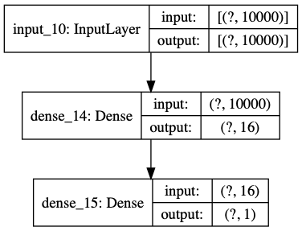

```python
imdb_ann = keras.models.Sequential([
    keras.layers.Input(shape = (X_train_1h.shape[1]), ),
    keras.layers.Dense(units = 16, activation = 'relu'),
    keras.layers.Dense(units = 1, activation = 'sigmoid')
])

imdb_ann.summary()

plot_model(imdb_ann, show_shapes = True, show_layer_names = True)
```

```python
imdb_ann.compile(optimizer = 'rmsprop', loss = 'binary_crossentropy',
                metrics = ['accuracy'])
```

```python
imdb_ann_history = imdb_ann.fit(
    x = X_train_1h, y = y_train, batch_size = 512, epochs = 20,
    validation_data = (X_val_1h, y_val)
)
```

```
Train on 23000 samples, validate on 2000 samples
```

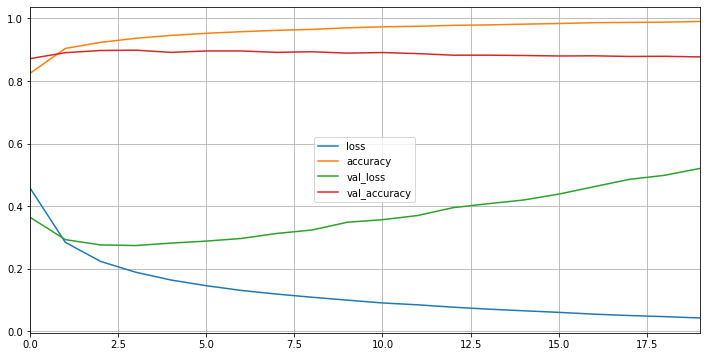

```python
pd.DataFrame(imdb_ann_history.history).plot(
    subplots = False, figsize = (12, 6), grid = True);
```

We see clear evidence of overfitting here. Just aftet two epochs, the validation loss reaches its minimum and begins to increase. We see a similar trend in validation accuracy, where the initial optimisation makes the accuacy close to 88% but there is not much improvement with increasing epochs.

By 20 epochs, the training loss is almost 0 and training accuracy is almost 1, suggesting severe overfitting.

Ideally, an early stopping callback should have been used with this model to rollback weights to those of epoch 2. The weights from epoch 20 will likely not generalize well to new data.

```python
imdb_ann_pred = imdb_ann.predict_classes(X_test_1h)
imdb_ann_accuracy = accuracy_score(y_true = y_test, y_pred = imdb_ann_pred)
print(f"ANN Accuracy: {np.round(imdb_ann_accuracy, 2)}")
```

```
ANN Accuracy: 0.85
```

This is sort of expected. We can see from the training history that, at its best, the outsample accuracy was slightly higher than that of the lasso regressor i.e. 89% compared to 88%. However, because of overfitting to the training data, the final weights don't generalize well to test data, resulting in a neural network that underperforms compared to a logisitic regression.

We should bear in mind that logistic regression model was heavily regularized (selecting only 25% of all predictors) whereas no such regularization took place in the NN.

# Example 06 - Recurrent Neural Networks

We try to fit recurrent neural networks with `Embedding` and `LSTM` layers and a more constrained feature space to see if this can improve on the performance of the simple feed forward neural network.

```python
# Reload the data so we're beginning with a fresh data set
(X_train, y_train), (X_test, y_test) = imdb.load_data(num_words = 10000)

# What is the shape of the original data?
print("X_train: ", X_train.shape)
print("X_test: ", X_test.shape)
print("y_train: ", y_train.shape)
print("y_test: ", y_test.shape)
```

```
X_train:  (25000,)
X_test:  (25000,)
y_train:  (25000,)
y_test:  (25000,)
```

```
Percentage of examples with <= 500 words:  92.0
```

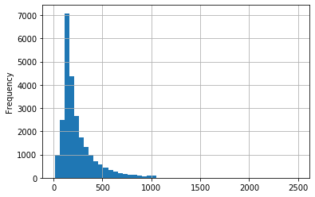

```python
# Find the lengths of each document, and check median
train_word_counts = np.vectorize(len)(X_train) # For efficiency
np.median(train_word_counts)
pd.Series(train_word_counts).plot(kind = 'hist', bins = 50, grid = True)
print(f"Percentage of examples with <= 500 words: ",
      np.round(np.mean(train_word_counts <= 500), 2) * 100)
```

We can see that the median word count in training data is 178 and 92% of all examples have ~500 words. This means we can restrict the document lenghts to the last $L = 500$ words and pad the beginning of the shorter ones with blanks.

```python
max_len = 500
X_train = pad_sequences(X_train, maxlen = max_len)
X_test = pad_sequences(X_test, maxlen = max_len)

# At this point, each the
print("X_train: ", X_train.shape)
print("X_test: ", X_test.shape)
```

```
X_train:  (25000, 500)
X_test:  (25000, 500)
```

```python
# At this point, each document is a list of 500 integers
# Each integer represents a word
# More specifically, it represents the index of that word in the word_dictionary
X_train[0, 489:]
```

```
array([  16, 4472,  113,  103,   32,   15,   16, 5345,   19,  178,   32],
      dtype=int32)
```